# ML_Assignment4

2023-02-10

# Part I: Implementing a Simple Prediction Pipeline

### Load packages

```r
library(Amelia)
library(caret)
library(tidyverse)
```

### Load needed data and Perform Data Cleaning

```r
set.seed(123)
health_data <-  read.csv("~/OneDrive - cumc.columbia.edu/2023 Columbia Spring/Machine Learning for Epi/ML_Learning_Module4/class4_p1.csv")

health_data$X<-NULL

str(health_data)
```

```
## 'data.frame':    3811 obs. of  16 variables:
##  $ chronic1    : int  2 2 1 2 2 1 1 1 1 2 ...
##  $ chronic3    : int  2 2 1 2 2 1 1 1 1 2 ...
##  $ chronic4    : int  2 2 2 1 2 2 2 2 2 2 ...
##  $ bmi         : num  26.8 28.2 39.2 42.5 22.3 ...
##  $ tobacco1    : int  3 3 1 3 3 3 3 3 3 2 ...
##  $ alcohol1    : int  3 3 2 3 NA 2 2 3 2 2 ...
##  $ gpaq8totmin : int  0 120 60 180 0 0 0 0 15 0 ...
##  $ gpaq11days  : int  5 5 3 5 7 7 7 5 5 7 ...
##  $ habits5     : int  3 1 1 2 2 3 2 3 4 2 ...
##  $ habits7     : int  NA NA NA NA NA NA NA NA NA NA ...
##  $ agegroup    : int  1 3 3 2 2 3 3 4 3 2 ...
##  $ dem3        : int  2 2 1 2 2 1 1 1 2 1 ...
##  $ dem4        : int  1 2 1 1 2 2 1 1 1 1 ...
##  $ dem8        : int  2 2 1 2 2 1 2 2 1 1 ...
##  $ povertygroup: int  1 3 6 2 6 3 4 6 3 1 ...
##  $ healthydays : int  24 30 NA 23 30 30 30 10 0 30 ...
```

```r
cols_to_keep_as_numeric <- c("gpaq8totmin" , "gpaq11days" , "healthydays", "bmi")
for (col_name in names(health_data)) {
  if (col_name %in% cols_to_keep_as_numeric) {
    health_data[[col_name]] <- as.numeric(health_data[[col_name]])
  } else {
    health_data[[col_name]] <- as.factor(health_data[[col_name]])
  }
}

health_tidy <- na.omit(health_data)
```

### Partition data into training and testing (use a 70/30 split)

```r
set.seed(123)
indexes <- createDataPartition(health_tidy$healthydays, p = 0.7, list = FALSE)

train_data <- health_tidy[indexes, ]
test_data <- health_tidy[-indexes, ]
```

### Feature selection by Backward Elimination Method

```r
set.seed(123)
selectf <- train_data
chooslinear <- lm(healthydays ~. , data= selectf)
summary(chooslinear)

selectf$dem3 <- NULL
selectf$dem8 <- NULL
selectf$chronic3 <- NULL
selectf$alcohol1 <- NULL
selectf$tobacco1 <- NULL
selectf$bmi <- NULL
selectf$gpaq8totmin <- NULL
selectf$gpaq11days <- NULL

chooslinear_2 <- lm(healthydays ~. , data= selectf)
summary(chooslinear_2)

selectf$povertygroup <- NULL
selectf$agegroup <- NULL
selectf$habits5 <- NULL
selectf$habits7 <- NULL

chooslinear_3 <- lm(healthydays ~. , data= selectf)
summary(chooslinear_3)
```

### Construct linear regression models to predict `Healthdays`

#### Model 1: Include 7 features:

##### *`chronic1` ,`chronic4` ,`dem4` ,`habits5`, `habits7`, `agegroup`, `povertygroup`*

#### Model 2: Include only 3 features:

##### *`chronic1` ,`chronic4` ,`dem4`*

```r
lm_model_1 <- train(healthydays ~ chronic1 +chronic4 +dem4 +habits5
                    +habits7 +agegroup +povertygroup,
      data = train_data,
      method = "lm")
summary(lm_model_1)
```

```
##
## Call:
## lm(formula = .outcome ~ ., data = dat)
##
## Residuals:
##      Min       1Q   Median       3Q      Max
## -30.4882  -0.5464   1.5436   3.6589  16.3626
##
## Coefficients:
##               Estimate Std. Error t value Pr(>|t|)
## (Intercept)   23.87961    1.30595  18.285  < 2e-16 ***
## chronic12      2.17106    0.44508   4.878 1.18e-06 ***
## chronic42      3.26454    0.76880   4.246 2.31e-05 ***
## dem42          1.11607    0.47231   2.363 0.018252 *
## habits52       0.08133    0.43946   0.185 0.853192
## habits53      -1.60754    0.57407  -2.800 0.005171 **
## habits54      -3.68388    0.95297  -3.866 0.000115 ***
## habits72      -0.38743    0.62036  -0.625 0.532380
## habits73      -0.95339    0.60725  -1.570 0.116622
## habits74      -2.85907    0.70450  -4.058 5.20e-05 ***
## habits75      -5.19548    1.02978  -5.045 5.07e-07 ***
## agegroup2     -1.21564    0.76937  -1.580 0.114305
## agegroup3     -2.57875    0.77144  -3.343 0.000850 ***
## agegroup4     -3.75521    0.82268  -4.565 5.41e-06 ***
## povertygroup2  0.09984    0.62266   0.160 0.872633
## povertygroup3  1.95572    0.62642   3.122 0.001830 **
## povertygroup4  1.41860    0.64995   2.183 0.029215 *
## povertygroup5  1.65996    0.61571   2.696 0.007095 **
## povertygroup6  0.20290    0.79638   0.255 0.798931
## ---
## Signif. codes:  0 '***' 0.001 '**' 0.01 '*' 0.05 '.' 0.1 ' ' 1
##
## Residual standard error: 7.154 on 1518 degrees of freedom
## Multiple R-squared:  0.1576, Adjusted R-squared:  0.1476
## F-statistic: 15.77 on 18 and 1518 DF,  p-value: < 2.2e-16
```

```r
lm_model_2 <- train(healthydays ~ chronic1 +chronic4 +dem4,
      data = train_data,
      method = "lm")
summary(lm_model_2)
```

```
##
## Call:
## lm(formula = .outcome ~ ., data = dat)
##
## Residuals:
##      Min       1Q   Median       3Q      Max
## -28.1990   0.5673   1.8010   3.5873  11.4009
##
## Coefficients:
##             Estimate Std. Error t value Pr(>|t|)
## (Intercept)  18.5991     0.8565  21.714  < 2e-16 ***
## chronic12     3.7663     0.4125   9.129  < 2e-16 ***
## chronic42     4.0474     0.7882   5.135 3.19e-07 ***
## dem42         1.7863     0.4583   3.898 0.000101 ***
## ---
## Signif. codes:  0 '***' 0.001 '**' 0.01 '*' 0.05 '.' 0.1 ' ' 1
##
## Residual standard error: 7.442 on 1533 degrees of freedom
## Multiple R-squared:  0.07943,    Adjusted R-squared:  0.07763
## F-statistic: 44.09 on 3 and 1533 DF,  p-value: < 2.2e-16
```

### Apply both models within the test data

```r
predictions_1 <- predict(lm_model_1, newdata = test_data)

predictions_2 <- predict(lm_model_2, newdata = test_data)
```

### Determine the preferred prediction model using appropriate evaluation metrics

```r
performance_1 <- postResample(pred = predictions_1, obs = test_data$healthydays)
print(performance_1)
```

```
##      RMSE  Rsquared       MAE
## 7.1668741 0.1248947 4.4125000
```

```r
performance_2 <- postResample(pred = predictions_2, obs = test_data$healthydays)
print(performance_2)
```

```
##       RMSE   Rsquared        MAE
## 7.43351826 0.05734531 4.71144940
```

Comments: As we known, based on these evaluation metrics, we can determine the preferred prediction model by comparing the values of MSE, MAE, RMSE, and R-squared for both models. A lower MSE, MAE, and RMSE and a higher R-squared indicate a better fitting model. After using the Backward elimination method, the model 2 results in a lower R squared and a higher RMSE compared to the model 1, this may suggest that the Backward elimination method may have reduced the model’s accuracy by removing important predictors. In this case, it may be best to stick with the model 1 that had a higher R squared and lower error metrics. Although the Backward elimination method has reduced the complexity of the model, making it easier to interpret, but at the cost of lower accuracy.So, I would prefer the model 1 as the prediction model. I would like to learn to make a better and more careful evaluation of the trade-offs between accuracy, complexity, and interpretability through the course process.

### Describle one setting where the implementation of your final model would be useful.

The implementation of this final model, “model 1”, would be useful in a public health setting to study the relationship between various health factors and self-reported number of healthy days. By considering variables such as hypertension (Chronic 1), asthma (Chronic 4), physical activity (habits5), diet quality (habits7), Hispanic/Latino ethnicity (dem4), age (agegroup), and household income (povertygroup), public health researchers can gain insights into how these factors may influence overall health and well-being. This information can then be used to inform public health interventions and policies aimed at improving health outcomes.

# Part II: Conducting an Unsupervised Analysis

### Load the USArrests dataset and packages

```r
# Load necessary libraries
library(dplyr)
library(tidyr)
library(ggplot2)
library(FactoMineR)
library(factoextra)
# Load USArrests dataset
data("USArrests")

# Scale the variables
USArrests_scaled <- scale(USArrests)
```

### Conduct a hierarchical clustering analysis

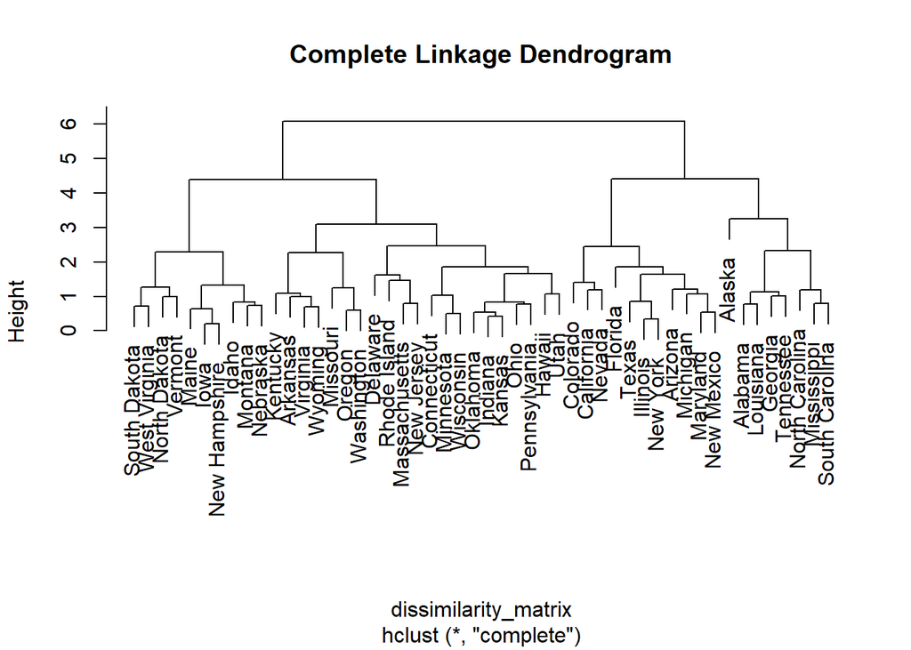

```r
# Calculate the dissimilarity matrix
dissimilarity_matrix <- dist(USArrests_scaled, method = "euclidean")

# Perform hierarchical clustering using the complete linkage method
hc.complete <- hclust(dissimilarity_matrix, method = "complete")

# Plot the dendrogram
plot(hc.complete, main = "Complete Linkage Dendrogram")
```

### Determine the optimal number of clusters

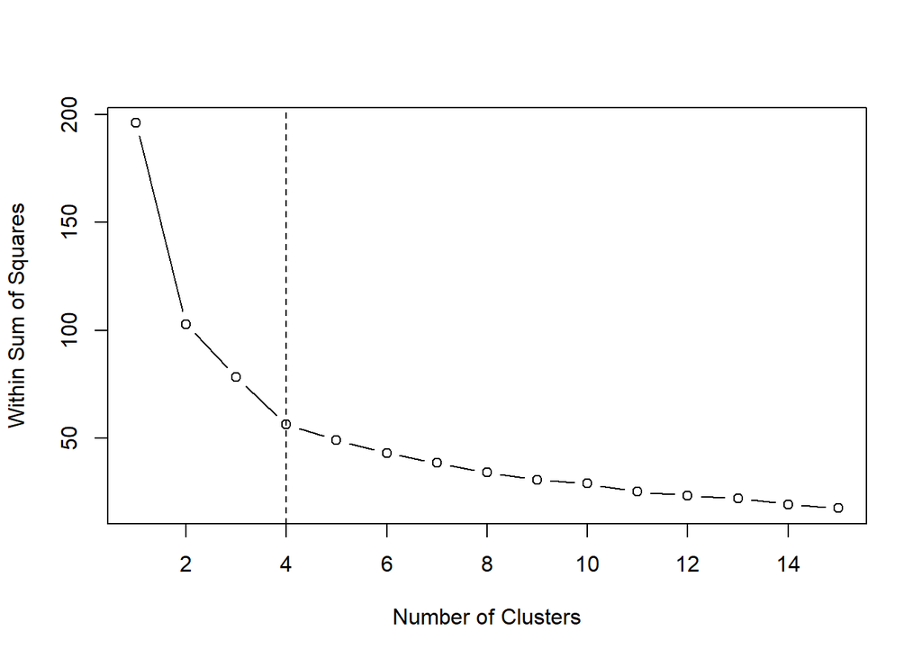

```r
# Using the elbow method
wss <- sapply(1:15, function(k){kmeans(USArrests_scaled, k, nstart = 100, iter.max = 100, algorithm = "Lloyd")$tot.withinss})
plot(1:15, wss, type = "b", xlab = "Number of Clusters", ylab = "Within Sum of Squares")
abline(v = 4, lty = 2)
```

Comment: According to the elbow method, the optimal number of clusters is 4.

### Describe the composition of each cluster

```r
# Cut the tree into 4 clusters
clusters_4 <- cutree(hc.complete, k = 4)

# Add the cluster information to the original data
USArrests_clusters <- data.frame(USArrests, cluster = clusters_4)

# Analyze the composition of each cluster in terms of the original input features
cluster_mean <- USArrests_clusters %>% group_by(cluster) %>% summarize_all(funs(mean))
```

Comment: The composition of each cluster can be seen by grouping the data by the cluster variable and summarizing the mean of each variable. After the calculation of mean, we can know cluster 1 has the highest average on murder. Cluster 2 has the highest averages on both assault, rape, and urbanPop. Cluster 3 only has relatively high average on urbanPop, the other features are relatively low. And cluster 4 has lowest averages on all the features.

### Describe one research question

If the data was from 2020, I think a potential research question: What the differences in crime rates between states in the United States in 2020 based on the four features in the USArrests dataset (Murder, Assault, Rape, UrbanPop) are? It probably can be addressed using the newly identified clusters. Set the newly identified clusters as the exposure variable. It is crucial to take into account both ethical and scientific issues before employing these clusters to answer a research topic. Considerations like the sample’s representativeness and the results’ applicability to other US states are important. Additionally, one should think about potential moral ramifications of using crime data and how the outcomes might be distorted or applied to stigmatize particular states, population groups.